# COVID-19確診人數與臺北捷運旅運量的關係

108072239 郭明晏

## 一、研究摘要

- 這20年來，臺北捷運已是雙北市民生活中不可分割的一部分。然而，由於2020年初嚴重特殊傳染性肺炎COVID-19在本土爆發，來勢洶洶的疫情使大眾的生活模式發生劇烈的改變，大家都變得不敢搭乘大眾運輸工具，造成台北捷運載客人數很大程度的影響。因此本研究想透過觀察捷運每日旅運量以及雙北每日確診人數，並將以時間劃分為2019年疫情尚未爆發期、2020年本土案例出現、2021年大規模感染、2022年與病毒共存等四個時期進行分析，探討COVID-19對於捷運旅運量的衝擊與影響。

## 二、研究流程

1. 收集資料：確診人數以**雙北（台北市加新北市）**計算
- [臺北捷運每日旅運量](https://www.metro.taipei/cp.aspx?n=FF31501BEBDD0136)
- [COVID-19雙北每日確診人數](https://covid-19.nchc.org.tw/city_confirmed.php?mycity=%E5%8F%B0%E5%8C%97%E5%B8%82)
2. 資料調整：處理缺失值，並以表格化方式呈現資料
3. 資料處理：將每日確診人數與每日旅運量整理，進行合併比較，並劃分為四個時期(2019,2020,2021,2022)
4. 資料分析：
- 找出相關係數
- 圖表呈現
5. 結論

## 三、資料呈現

### 臺北捷運每日旅運量

- 由於臺北捷運官網只公布到今年5月旅運量，故資料取到2022/5/31
- 用`select`選取所需資料：日期、每日旅運量
- 以`as.POSIXlt`進行日期格式轉換，時間從遠至近排序
- 每日旅運量指派給`total_volume`

### COVID-19雙北市每日確診人數

#### 台北市每日確診人數

#### 新北市每日確診人數

- 由於原始檔案只顯示有確診的天數，故須補齊從2019~2022年的缺值
- 建立內容為空的資料框架，並把現有資料放進空的框架使時間變連續，補足確診為0的天數
- 由於旅運量的緣故，每日確診數也只取到2022/5/31
- 用`select`選取所需資料：個案公佈日、新增確診人數
- 以`as.POSIXlt`進行日期格式轉換，時間從遠至近排序
- 台北市每日確診人數指派給`final.data_new_taipei`
- 新北市每日確診人數指派給`final.data_taipei`

### 雙北每日確診人數和每日旅運量之資料彙整

```r
#將新北市和台北市每日確診數的dataframe結合(雙北確診人數加總)
z<-cbind(final.data_new_taipei,final.data_taipei)
z1<-dplyr::select(z, -c(個案公佈日,區域,累計確診人數,個案公佈日_n,區域_n,累計確診人數_n))
z2<- cbind(z, total_confirmed = rowSums(z1))

total_covid<-dplyr::select(z2, -c(新增確診人數,區域,累計確診人數,個案公佈日_n,區域_n,累計確診人數_n,新增確診人數_n))

#combine two final dataframes 確診人數合併旅運量
total1<-cbind(total_covid,total_volume)
total<-dplyr::select(total1, -c(Date))

kable(total) %>%
  kable_styling() %>%
  scroll_box(height='200px')
```

|  | 個案公佈日 | total_confirmed | Station Volume |
| --- | --- | --- | --- |
| 3223 | 2019-01-01 | 0 | 1628886 |
| 3221 | 2019-01-02 | 0 | 2252978 |
| 3218 | 2019-01-03 | 0 | 2269048 |
| 3216 | 2019-01-04 | 0 | 2448988 |
| 3214 | 2019-01-05 | 0 | 1951667 |
| 3212 | 2019-01-06 | 0 | 1557160 |
| 3210 | 2019-01-07 | 0 | 2185682 |
| 3208 | 2019-01-08 | 0 | 2222106 |
| 3206 | 2019-01-09 | 0 | 2244563 |
| 3204 | 2019-01-10 | 0 | 2290502 |
| 3202 | 2019-01-11 | 0 | 2494932 |
| 3200 | 2019-01-12 | 0 | 2074242 |
| 3198 | 2019-01-13 | 0 | 1773966 |
| 3196 | 2019-01-14 | 0 | 2192358 |
| 3194 | 2019-01-15 | 0 | 2232255 |
| 3192 | 2019-01-16 | 0 | 2243466 |
| 3190 | 2019-01-17 | 0 | 2269923 |
| 3188 | 2019-01-18 | 0 | 2526685 |
| 3186 | 2019-01-19 | 0 | 2351756 |
| 3184 | 2019-01-20 | 0 | 1841643 |
| 3182 | 2019-01-21 | 0 | 2241036 |
| 3180 | 2019-01-22 | 0 | 2256106 |
| 3174 | 2019-01-23 | 0 | 2315776 |
| 3167 | 2019-01-24 | 0 | 2334810 |
| 3159 | 2019-01-25 | 0 | 2513568 |
| 3144 | 2019-01-26 | 0 | 2172969 |
| 3129 | 2019-01-27 | 0 | 1896648 |
| 3111 | 2019-01-28 | 0 | 2303673 |
| 3093 | 2019-01-29 | 0 | 2288084 |
| 3073 | 2019-01-30 | 0 | 2321252 |

[output cut: 1217 more lines]

- 由於2019/01/01~2020/02/20疫情尚未爆發，故確診數皆為0
- 建立新變量`total_confirmed`:新北市加台北市每日確診人數
- 以`select`讀取所需資料：個案公佈日、雙北總確診人數、每日旅運量
- 用`cbind`將雙北每日確診人數和每日旅運量的dataframe結合
- 用`kable`呈現滾輪式表格

```r
total_covid_from_begin<-total[416:1247,]
total_2019<-head(total,365)
total_2020<-total[366:731,]
total_2021<-total[732:1096,]
total_2022<-total[1097:1247,]
```

- 將2020/02/20(第一例本土疫情爆發)~2022/5/31的資料指派給`total_covid_from_begin`
- 將最終彙整資料`total`以年份進行切割，指派為`total_2019`,`total_2020`,`total_2021`,`total_2022`
- 會選取2019年的旅運量是因為想呈現**疫情尚未爆發之前**，正常時期的每日旅運量變化，從而進行比較

## 四、結果分析

- 根據上面蒐集的資料進行分析，觀察雙北每日確診人數與捷運旅運量是否有關連

### 雙北每日確診人數與捷運旅運量的趨勢圖(2019~2022)

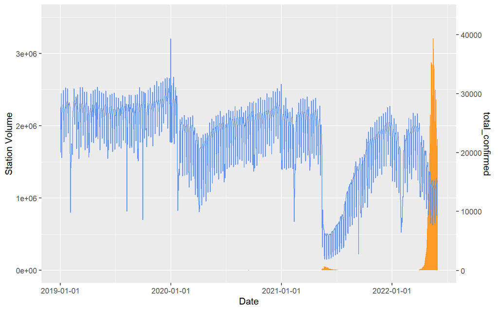

```r
parameter <-  max(total$`Station Volume`) / max(total$total_confirmed)
total %>%ggplot() +
  geom_bar(stat='identity', aes(x=個案公佈日,y=total_confirmed*parameter),color='#FD9A28',width=2)+
  geom_line(aes(x=個案公佈日,y =`Station Volume`),color='cornflowerblue')+
  scale_x_datetime(labels = date_format("%Y-%m-%d"))+
  scale_y_continuous(limits = c(0,3500000),sec.axis = sec_axis(~./parameter , name = "total_confirmed"))+
  labs(y='Station Volume',x='Date')
```

- **藍色線**：捷運每日旅運量
- **橘色長條**：雙北每日確診人數
- 用`ggplot2`繪製從2019~2022年確診數及旅運量的整體趨勢
- 定義`parameter`為右邊y軸的尺度相對於左邊y軸尺度放大的倍數，讓確診數在圖表上有更明顯的趨勢
- 用`scale_x_datetime`使x軸以日期格式呈現
- 利用`sec.axis`設定右邊y軸幅度，並將其命名為`total_confirmed`
- 初步可以觀察到在2021/05以及2022/05兩個確診人數大幅增加的期間，捷運旅運量皆有一定程度的下降

```r
cor(total_covid_from_begin$total_confirmed,total_covid_from_begin$`Station Volume`)
```

```
## [1] -0.199821
```

- 用`cor`計算從疫情爆發到現今(使用`total_covid_from_begin`的資料) 雙北每日確診人數和捷運每日旅運量的相關性
- 發現兩者**呈微弱的負相關**
- 由於時間軸過長，無法找出確切的相關性，故把時間切分為四年來看

### 雙北每日確診人數與捷運旅運量的趨勢圖(2019)

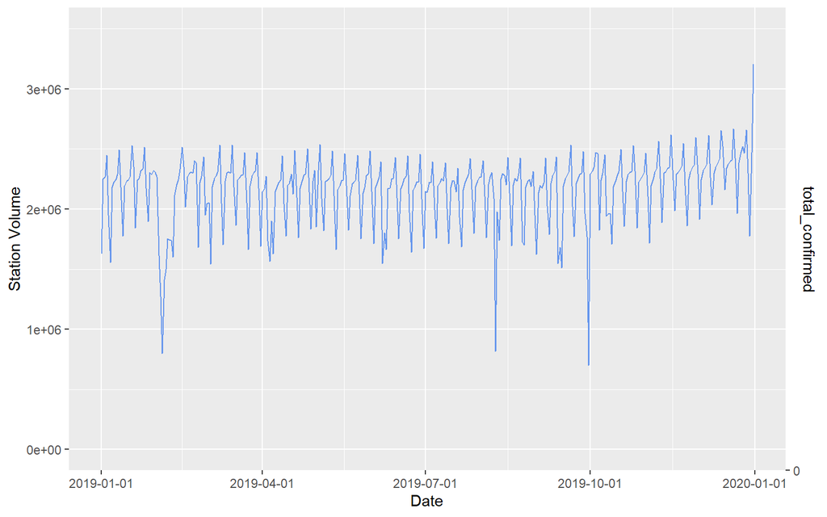

- 可觀察正常情況下的每日旅運量變化(每日旅運量平均落在200萬人次)
- 疫情尚未爆發，故整年確診數皆為0
- 兩者無相關性

### 雙北每日確診人數與捷運旅運量的趨勢圖(2020)

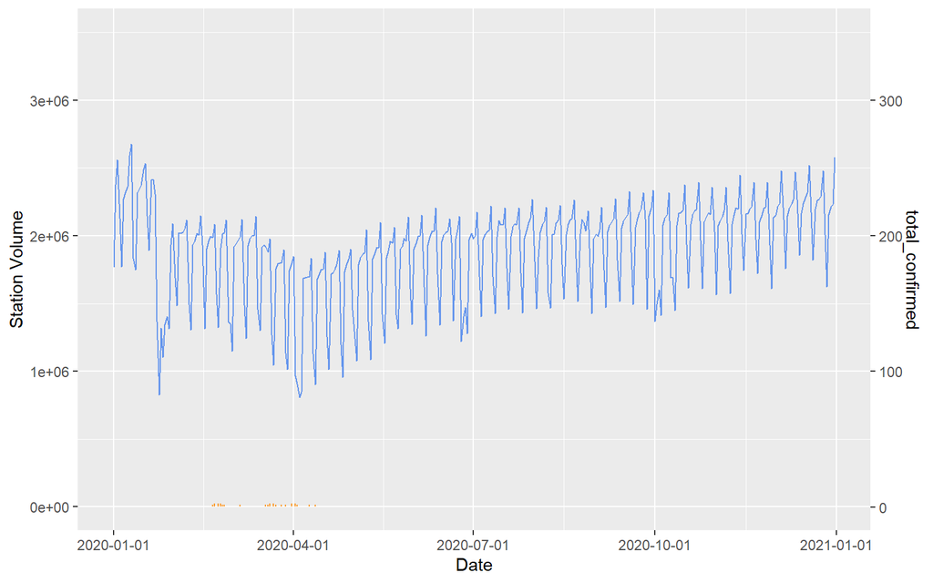

- 在2020/02/20爆發第一例本土案例後，3,4月雙北的每日確診人數皆為1~2人，故在圖表上無明顯變化(只有3,4月附近的橘色小點)

```r
cor(total_2020$total_confirmed,total_2020$`Station Volume`)
```

```
## [1] -0.1711955
```

- 相關係數為-0.1711955，呈**微弱的負相關**
- 除了3,4月雙北零星確診數外，2020其他天皆為0確診，故兩者相關性低
- 可以觀察到在疫情爆發初期，旅運量還是有稍微下降，但在連續幾個月的加零下，還是恢復平均旅運量

### 雙北每日確診人數與捷運旅運量的趨勢圖(2021)

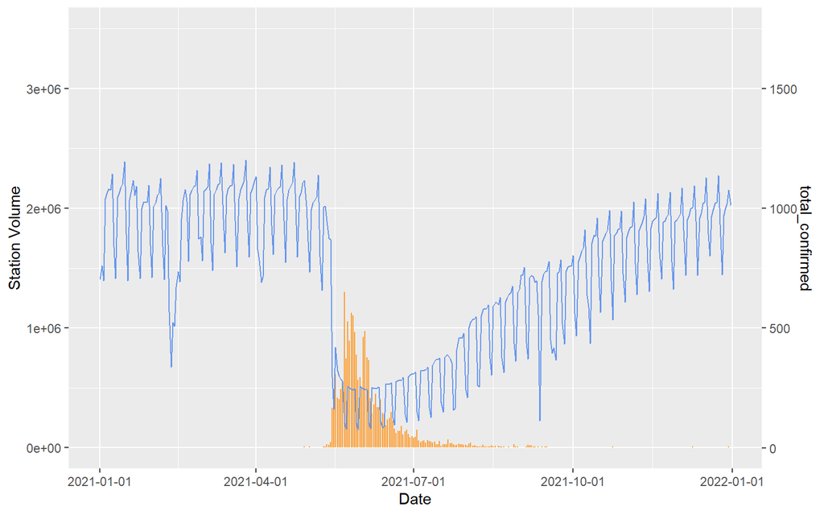

- 2021年5月中疫情大幅爆發，單日確診破百，且在05/15雙北發布第三級警戒後，由於外出受到了限制，**捷運旅運量大幅下降**，甚至一度低於20萬

```r
cor(total_2021$total_confirmed,total_2021$`Station Volume`)
```

```
## [1] -0.5259965
```

- 相關係數為-0.5259965，**負相關性高**
- 和其他三年比較，2021年的確診數及旅運量相關性**最高**

### 雙北每日確診人數與捷運旅運量的趨勢圖(2022)

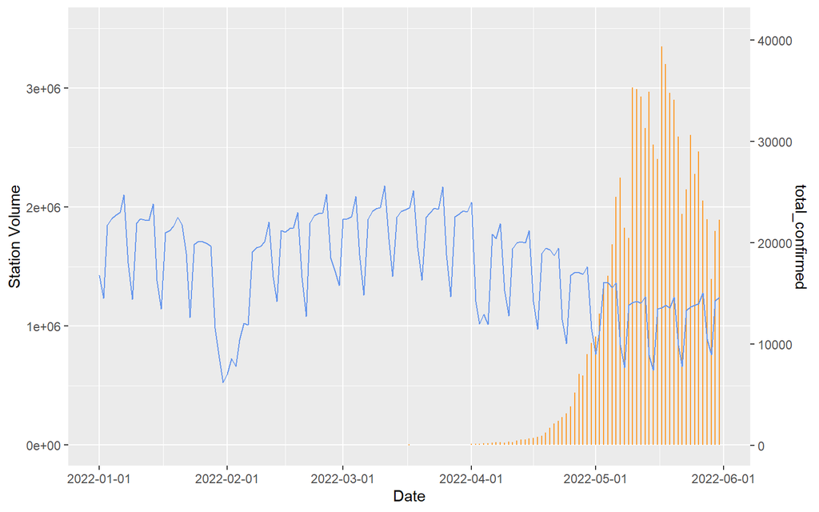

- 因為時間只取到2022/05/31，故圖表較鬆散
- 每日平均旅運量下降，落在150萬左右
- 今年政府決定採取與病毒共存的政策，即使5月後每日確診破萬，每日旅運量的下降幅度也不再像去年這麼明顯

```r
cor(total_2022$total_confirmed,total_2022$`Station Volume`)
```

```
## [1] -0.4921586
```

- 相關係數為-0.4921586，**負相關性高**
- 雖然雙北每日確診數已破萬，但大眾對於COVID-19趨漸採取共存的態度，且沒有三級警戒限制外出，故相關性降低

## 五、研究總結

- 從2019~2022年整體趨勢來看，雙北市每日確診人數與捷運每日旅運量關聯性較低，推測是受到時間軸太長的影響，故將資料集分成四年分析：
  - 2019年疫情尚未爆發期，只需觀察每日旅運量的正常變化。
  - 2020年第一件本土案例出現，但每日確診只有1~2人，故相關性較低。
  - 2021年大規模感染期，單日確診破百，且在5月實施三級警戒，大眾運輸受到嚴重影響，故相關性是四年中最高。
  - 2022年與病毒共存期，單日確診破萬，但大眾已開始習慣這樣的生活方式，旅運量受疫情影響相比去年較小，故相關性稍微下降。
- 在分析2022年相關性下降的原因時，我認為除了考慮大眾對疫情的心態轉變外，還要考慮到其他因素，例如：疫苗覆蓋率。2022年台灣的疫苗覆蓋率(已施打兩劑)已達到82.67%，大家對於外出也不再那麼懼怕，因此搭乘捷運的人又更多了。
- 此次的研究結果也與我這幾年來搭乘臺北捷運的實際觀察吻合！

## 六、回答問題

### 想法來源：

- 我在選取final project的題材時，想從日常生活方面著手，因此想到了平時常常在搭乘的捷運系統，而這幾年大家的生活深受COVID-19的影響，所以藉由此次研究探討雙北市COVID-19確診人數及捷運旅運量的關係。

### R指令的使用：

- `dplyr`的`select`進行欄位選取
- `ggplot2`繪製折線圖、直方圖等，以視覺化呈現數據分析
- `tidyverse`的`%>%`
- `cor`計算相關係數

### 新套件、指令的運用：

- `rmdformats`套件中的`readthedown`呈現整體頁面設計
- `kableExtra`使表格以滾輪式呈現，並設定欄位高度
- `Hmisc`提供計算該年總天數之函式
- `zoo`提供可協助處理時間的資料型態之函式，例如：`as.Date`可將值轉成日期資料型態
- `scales`中運用`scale_x_datetime`使畫圖時可讀取特殊日期格式、`sec.axis`可設定第二個y軸的值和標題

### 最困難的部分：

1. 資料呈現：尤其是處理雙北每日確診人數時，因為需要補足確診數為0的天數，並調整確診人數的日期格式，使其能和每日旅運量進行合併。
2. 圖表呈現：因為資料量大，且確診人數變動幅度劇烈(0~30000 up)，故在調整每一年的y軸呈現方式時，為了讓視覺上更好辨識又不失真實性，花費較多時間。